# Critical Graphs: Shenanigans with Critical Role Season 1 subtitles

With the end of season two approaching, it is time to look back on the humble beginnings of the show “Critical Role”. What is “Critical Role” you ask? To use their own words: it’s a bunch of nerdy ass voice actors who sit around and play Dungeons and Dragons. Thousands around the world tune in to watch them [live](https://www.twitch.tv/criticalrole) and millions view their shenanigans later on [YouTube](https://www.youtube.com/criticalrole). The fact that nothing is scripted makes this show so thrilling to watch: as nobody writes out an episode beforehand, whatever happens is up to the players and the dice to decide. Everything is possible and only happens in the imagination of the players and the viewers. That’s what makes it so intriguing to watch. The creativity also makes the show interesting for some nerdy ass data analyses. Be aware: minor spoilers ahead.

The large online community of the show provided subtitles for every episode of the first season. These can be used to construct data sets, which we then can use for analyses of language, text and interactions during the show. Rameshkumar and Bailey (2020) use these to construct a data set to test models, which predict the text word of a text (similar to what you may find in your phone when typing a message). The unscripted nature of the show makes the dialogue less predictable than other text and therefore makes it a good test for these algorithms.

However, Rameshkumar and Bailey’s approach omits time stamps from the data and focuses on dialogue entirely. While this approach is reasonable when predicting the next word, leaving out time from the data excludes interesting information. For example, one may potentially use the subtitles and the videos of the episodes to train a neural network, which then act out an entire episode in the future. This is, however, far beyond the scope of this blog post. Instead, we will examine at descriptive statistics to look back on the first season of the series.

In total the subtitles for the first season cover over 431 hours of game play and contain roughly 3.4 million words. A typical episode might start with the game master Matthew Mercer saying: “Hello everybody and good evening. Welcome to Critical Role.” In the subtitles this looks as follows:

> 00:00:00,500 –> 00:00:04,043 MATT: Hello, everyone and good evening. Welcome to Critical Role, a show where a bunch of us 00:00:03,307 –> 00:00:06,503 nerdy-ass voice actors sit around and play Dungeons & Dragons.

The numbers indicate the time during which a subtitle is shown on the screen. Doing some coding and data cleaning we can turn this into a nicer format, which ultimately looks as follows:

[output not shown]

To achieve this, we have to extract the speaker from the text and combine the different parts of the text into one. Unfortunately, not every volunteer followed the same naming convention. For example, when the game master, Matt, is acting as a character in game, this can either be written in the subtitles as the character’s name (say, ‘guard 1’) or as ‘Matt’. The same applies for the players, who may be referred to by their name or their character’s name. Additionally, as is inevitable when transcribing long spoken text (an average episode is 3.8 hours long), people make mistakes. Which brings us to the first interesting question to ask: which actor got misspelled the most? This can give an indication of how useful the subtitles are when examining the series is further detail.

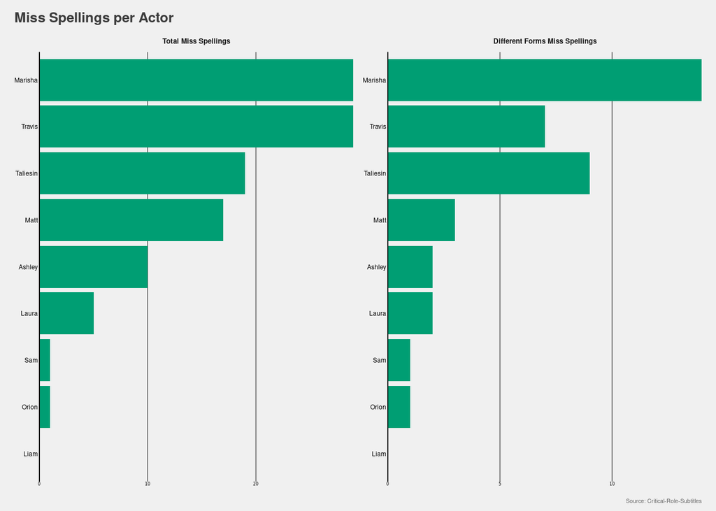

The graph above directly compares the miss spellings of the different actors. However, a direct comparison may be unfair because not every actor has the same chance of being misspelled. This is because of two reasons: first, not every actor was present for all episodes. Second, not every actor spoke for the same amount of time. While Matt, as the game master, must be present for every episode and has to describe everything that happens in game, other actors can give short answers or sit out an episode. So, let’s look at both attendance and the amount of dialogue in turn.

Examining the attendance by the players some differences stand out: Out of the eight players, five didn’t miss more than 5 out of the total 115 episodes. Meanwhile, Ashley was only present for less than half of the episodes. Similarly, Orion only participated in every fifth episode because he left the show after only a quarter of the episodes. Hence, it seems reasonable that he got misspelled less compared to many of the other cast members. We can also see that about one in five episodes guests joined the show.

[figure not shown]

Now let’s look at the amount of time the actors speak. We can do so in three different ways. First, we can look at the time a cast member speaks. Second, we can examine the number of words as metric to compare the amount of speaking of the different players. Third, we can use the number of turns for each actor. Turns are numbers indicating the number of changes for which person speaks. For example, turn one might be Matt saying “hi”. Turn two might be Liam responding with “hi, how are you doing?”. All three measure give us some indication on much different actors speak. While the time an actor speaks tells us how much time they say something compared to the rest of the cast, the number of turns can tell us how often they speak. Last, the number of words used tells us how often the actors say something.

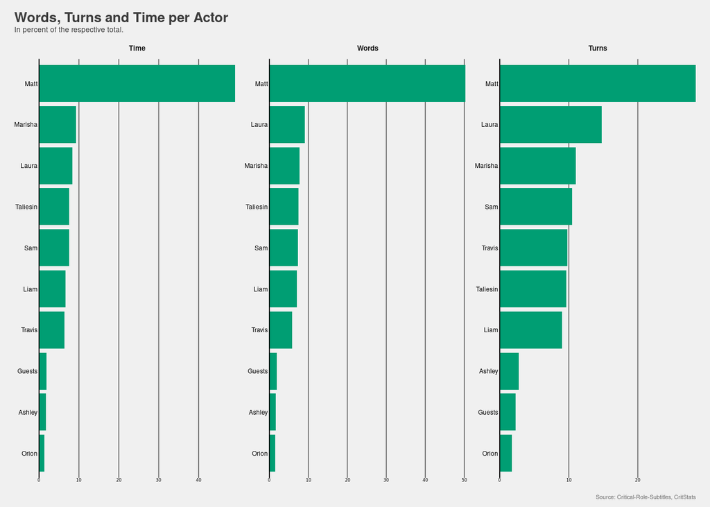

Unsurprisingly, the graph above shows that Matt speaks most of the group. After all, a game master must describe how everything looks and feels in game. He acts out non-player characters and their reaction to the actions of the players. Lastly, he describes how the actions of the characters are playing out in the imaginary world. In total, he speaks half of the time and says half of all words. However, he only uses roughly very fourth turn to do so. This may be surprising as, especially in combat, every turn by a player is usually followed by a description by Matt. However, this also indicates how important role play among the players is for the series (we will investigate the significance of role play later in more detail when we look at the different arcs of the story).

Like in the miss spellings, we examined above, Marisha tops the list of time spoken compared to the other players. Interestingly, both Ashley and Orion only speak roughly the same as all guests of the show combined. This is a testament to the fact that they’re not present for all episodes. Laura uses more words than Marisha even though she speaks for less time. Moreover, we can see that she uses more turns compared to any other member of the cast. This may imply that she speaks at a quicker pace compared to the other cast members. However, as we can see in the graph below, this is not the case. Instead, Orion speaks the fastest at a speed of 200 words per minute.

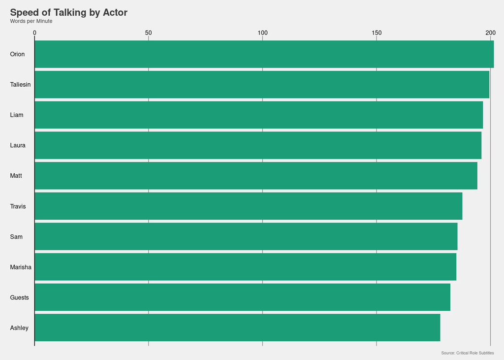

Yet there is a catch to these numbers, as not everything that is said is shown in the subtitles. Sometimes many people speak at the same time. If that happens only the important parts are written in the subtitles. This affects the calculated time the actors speak, as it is measured by the time subtitles are shown on the screen. For example, a long description from Matt may span over 30 seconds. If one of the players were to comment on the scenery at the same time it may be omitted from the subtitles.

Despite these shortcomings, we can still look at the most used words per actor to see if players use a set of unique words often. To do so we can calculate the log-odds ratio for the words used by the players. A high log-odds ratio tells us that if a given spoken text contains a specific word, it is more likely to be said by a certain cast member. For example, the graphs below show that if a text contains the word ‘inspire’ it is likely to be said by Sam who plays the bard Scanlan. As ‘inspire’ is a class ability of bards, it is not surprising that Sam uses that word that often. Similar relationships between class abilities and what the player said can be found for almost all players. Among others, Laura’s list contains parts of the iconic ranger ability “hunter’s mark”, while Travis’ includes the barbarian ability “reckless”. Taliesin’s “sharpshooter” feat and can be seen in the graph.

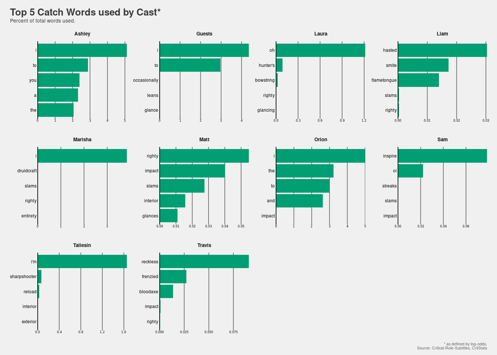

What we can do easily though is to investigate, which cast member used the most elaborate vocabulary. A commonly used measure to examine the readability of text is the [Coleman–Liau index](https://en.wikipedia.org/wiki/Coleman%E2%80%93Liau_index). It uses the number of words, letters, and sentences to calculate a score, which then can be translated into grades. Score of five or below indicates very easy to read text and can be used for kids in 5<sup>th</sup> grade or below. A score of six characterizes text, which is easy to read and can be used for children in grade 6. Higher scores can be translated into school grades in a similar fashion.

As we can see in the graph below, the show is easy to follow. This is hardly surprising as it is essentially one long conversations between cast members. As most of us don’t speak like academic papers are written this results in a good readability of the dialogue. The only member of the crew, who scores higher than a six on average is Matt. This is to be expected as he has to flesh out the world for everyone. In contrast, all the players get a mean score of 4 or below. Only Talisien achieves a score of four. Maybe surprisingly, Ashley has the easiest to follow text. However, this could also be because Ashley is only present for half of the episodes and her character, Pike, is rather shy. Please note, in the interest of keeping this light on spoilers, I intentionally do not differentiate between different characters played by the same actor. Some of the differences may be driven by players playing different characters throughout the show. That said, only a few players change characters throughout the show and should therefore not influence the results significantly.

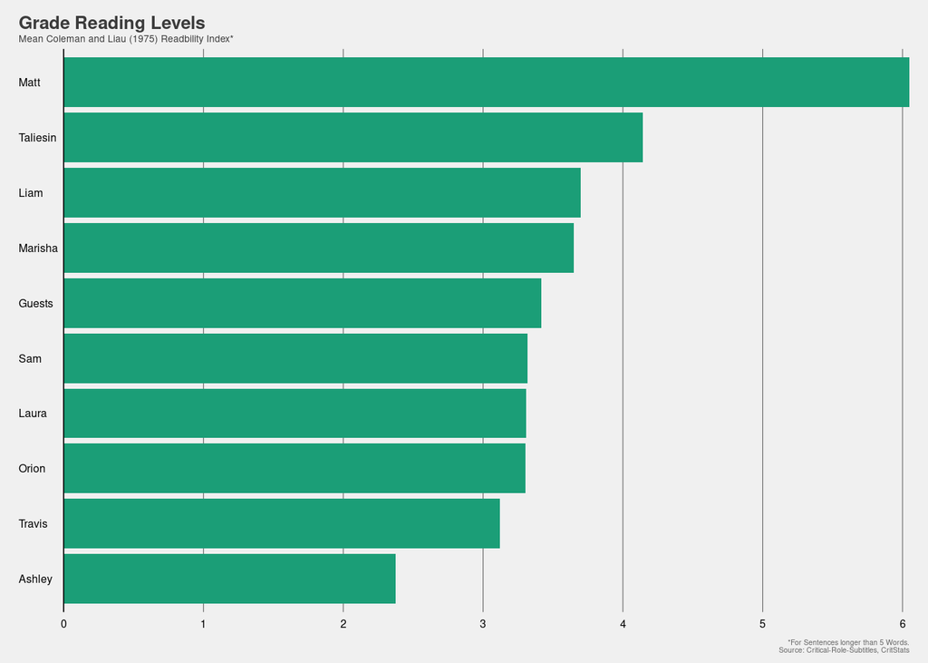

So far, we have only looked at each actor individually. As Dungeons and Dragons is an interactive experience, this seems restrictive. The graph below maps out interactions between players. In total, we see that Laura has the most interactions with everybody. Surprisingly, given how the story evolves, she interacts with Taliesin the least out of the regular cast. Likewise, Marisha interacts more with Taliesin than with Liam. However, we can see that Travis often speaks before and after Sam, who act as kind of the chaos duo during the show (anybody looking for Suude?). Moreover, we can also examine whether people, who sit nearer to each other talk to each other more often. This does not seem to be the case (the correlation coefficient is -0.11). It will be interesting to examine the interactions in season two as well, as both, the characters played by the actors and the seating arrangement, was changed in the new studio.

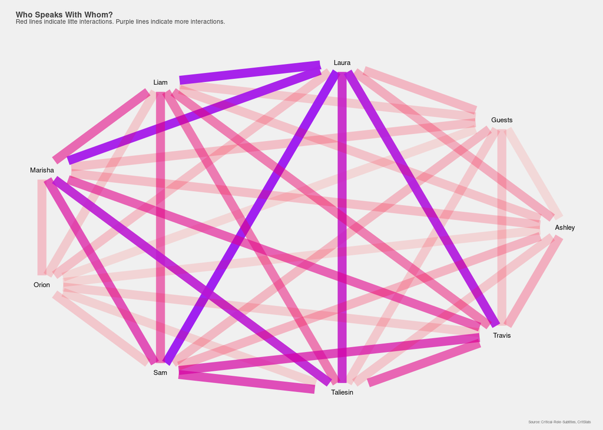

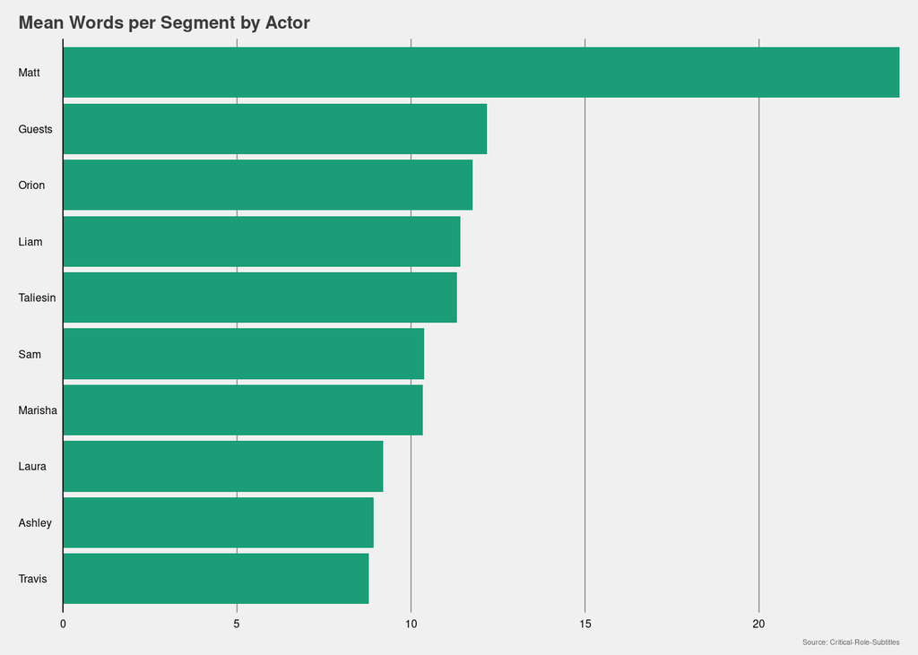

Sometimes actors may say precisely the same thing simultaneously: For example, when a party member is close to dying in a fight, they may have the same reaction. In the subtitles this may be shown as follows: “Ashley and Laura: no no no no!”. So, let’s examine who tends to say the same thing at the same time.

Similarly, to the interactions earlier, we can see that Laura has the most shared spoken text with her cast members, indicating that she indeed has the briefest comments from the group. Out of the cast, she and Marisha often share the same thoughts out loud. Marisha and Taliesin often share the same ideas as well. The same applies to Ashley, Laura and Travis or Sam and Taliesin respectively, though to a lesser extent. Interestingly, Matt never says the same thing at the same time with a guest.

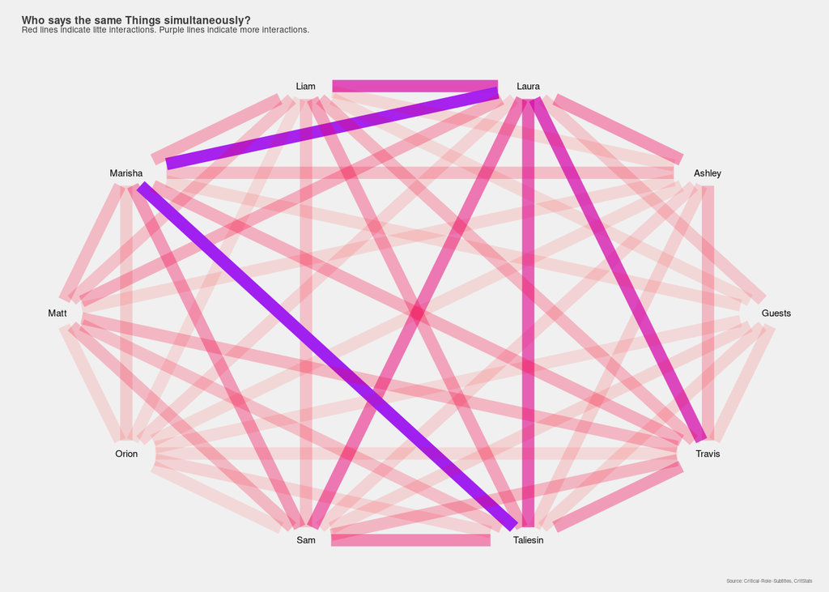

So far, we focused entirely on the cast. While this interesting, for fans, who finished both season one and two, the more interesting question might be: which episodes and arc should I watch again? We can use sentiment analysis to examine, which character, arc or episode is the most happy or sad. To fully understand a human being, non-spoken elements such as body language matters a lot too. However, the approach can be used to give us a rough first indication. When applying sentiment analysis, we which assign specific words or sentences happy or sad sentiments using the Lexicoder Sentiment Dictionary. Using this dictionary, higher values indicate a happier dialogue. These values can then be used to examine which characters express themselves in the happiest and the saddest way. As we have seen earlier, different actors have different speaking times. Thus, to make it comparable, let’s look at the mean sentiment of sentences spoken per actor. As this will give us some hints towards the personal journey of characters, be wary of spoilers (and mimics) from now on.

Looking at the sentiment scores from actors some differences become clear. To begin with, Liam and Travis seem to be playing the saddest characters. For Liam this hardly seems surprising as he previously stated that Dungeons and Dragons serves as an outlet for him. For Travis this may be because Grog often gets told he cannot do a lot of stuff or because he plays the character with the lowest intelligence. In contrast, the guests seem to be happier than most of the cast. This may be because they are happy to play with the group or that Matt intentionally makes episodes starring guests more light-hearted. Likewise, Ashley seems to be the good heart of the group. Yet, Orion stands out as the happiest of the cast. This is a bit surprising as he is only present in the first episodes. However, as viewers of the first season know, the story gets darker after his departure. To quantify this, let’s investigate whether later arcs are indeed less happy compared to the earlier ones.

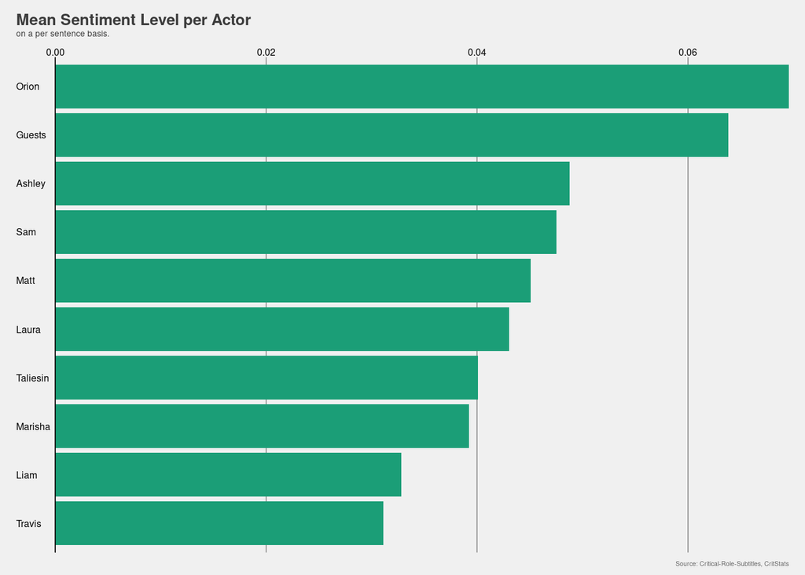

Examining the mean sentiment per episode for the different arcs we can indeed see that the first two arcs were happier compared to most other ones. After a happy start and everybody getting accustomed to streaming and watching Dungeons and Dragons on a live stream, the story takes a darker turn. The exception to this rule is the ‘Daring Deeds’-arc. This seems hardly surprising for viewers of the show given how a new character was introduced and how the story develops during their presence. In the interest of keeping this text light on spoilers, let’s not drive into the story any further. Instead let’s investigate whether the difference in sentiment was driven by differences in the amount of combat. As more combat represents higher chances of dying, this may be a driving force behind the differences between the arcs. Luckily, the team at [CritStats](https://www.critrolestats.com/) keep track of the time spent in combat.

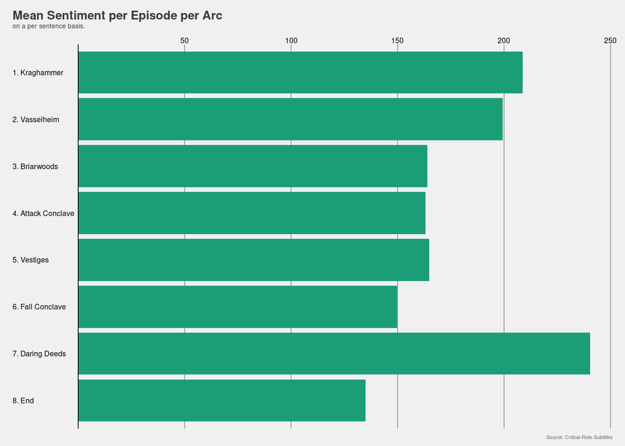

As we can see below, the earlier arcs had more time dedicated to combat. During the search for the Vestiges of Divergence the time spent in combat is the lowest (20percent). In the last three arcs, around a quarter of the time was dedicated to combat. However, this means that combat may not be the driving factor behind sad moments in the story but can be found in role-play as well. Thus, it could be that in the beginning of the show players were less comfortable with the rules as they use a different rule set when they started to play onscreen.

Additionally, before streaming, the group didn’t play on a set schedule. Consequently, it seems likely that the players got more used to playing their characters and the abilities they have. Thus, estimated time does not necessarily reflect the in-game time in combat. To investigate the issue further let’s look at the happiest and saddest episodes to see whether they involve combat. As these episodes may also be the ones which drive much of the story forward the next paragraph contains spoilers for the uninitiated (but may also be worth to be watched again).

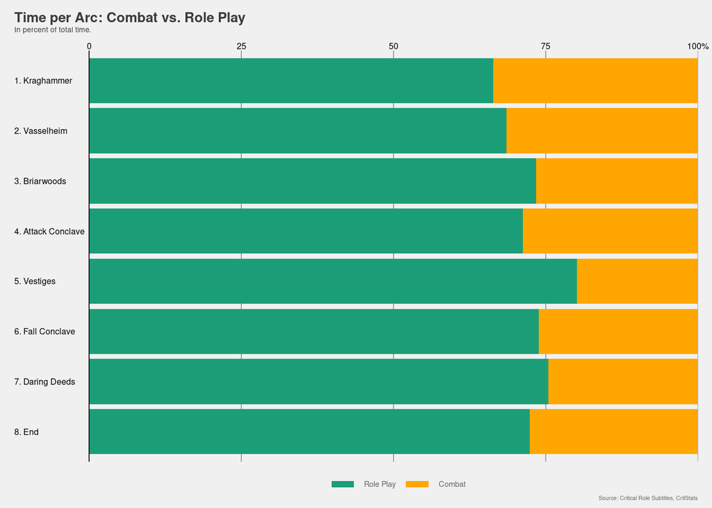

Looking at the happiest episodes a lot of the findings we have gathered so far come together. On the one hand, the top scoring episode involves the introduction of the already mentioned new character. Additionally, episode 95 involves the reunion after a one-year break in game and is more light-hearted. Yet, the other three episodes involve combat and guests. While episode 11 involves a lot of (useless) planning while attacking a temple, episode 88 involves fighting a kraken. Moreover, episode 18 involves two guests and parts of the cast absent. This ties in nicely with the results we obtained earlier that guests were genuinely happy to team up with Vox Machina.

In contrast, most of the saddest episodes involve combat. This is surprising given that we found earlier that combat and sentiment are not related on when we examined entire arcs. Yet, as an arc contains multiple episodes the relationship was masked by averaging the numbers. The saddest episode (51) even has a negative score, meaning that the average sentences spoken during the episode has a sad connotation. It involves planning to help the child of one character to escape a city, while simultaneously fighting the uncle of another. Episode 68 features the fight against an antagonist and the death of one of the characters. As the other episodes on the list take place during the last arc and are preparation for the final boss fight, I will not discuss them in more detail. Instead, let’s look in more detail what drives the sentiment of an episode. So far, we have seen that the guests and Ashley had the happiest sentiment. We have also seen that time spent in combat and sentiment do not seem to be related when looking at entire arcs. However, having obtained mixed signals when looking at individual episodes, let’s investigate what exactly makes a happy or sad “Critical Role”-episode.

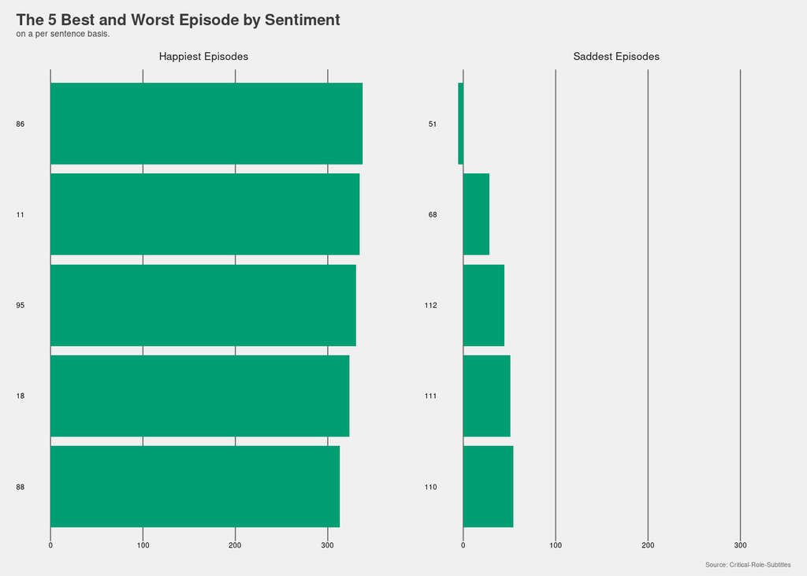

First, let’s see whether episodes starring Ashley and guests are happier compared to episodes without. As we have seen earlier both, guests and Ashley had higher sentiment scores compared to the rest of the group. We might expect this to translate to happier episodes in general. However, when we run correlation tests, we find insignificant results. This means that episodes starring Ashley or a guest are not different from episodes without them when it comes to sentiment.

In contrast, the time spent in combat does seem to negatively effect the sentiment of an episode. Using a OLS estimation, while holding the length of episodes constant, we can estimate the effect. We find that one hour spent in combat is associated with a decrease 27.23 in the sentiment score of the episode. Given that an average episode has a sentiment score of 176 and an average combat lasts for 1.4 hours this is a significant effect. Yet, as success in Dungeons and Dragons is dependent on the dice rolls made, let’s investigate the effect of those on the sentiment as well.

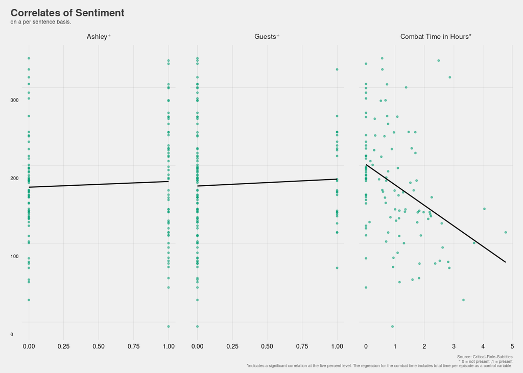

When we look at all the rolls made during the combat, we don’t find any relationship between dice rolls and happy sentiments (see first panel in the graph below). Yet, as always there is a caveat to these numbers. As players gain in levels, they also roll higher as they character get stronger. At the same time, they must achieve higher rolls to be successful as well. Thus, a high roll when modifiers are applied do not yield the same excitement in later episodes compared to later ones. Hence, we can only use the natural value rolled for the average of all dice rolls. However, this reduces the total number of dice rolls significantly as not often we only know the total outcome (meaning including abilities modifiers). Still, we often know when the players and the dungeon master roles a critical success (20 on 20-sided die) or a critical failure (1 out of 20). We can use these to investigate the relationship between dice rolls and the sentiment of an episode. Yet, when we run the numbers, we don’t find associations between critical rolls and the sentiment of episodes. Similarly, the number of face palms by Matt does not seem to be a good indicator either.

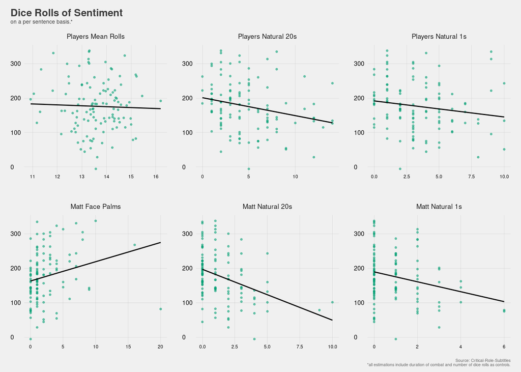

In summary, we can say that subtitles for Critical Role can be used for some funny data analyses. Taken together they can give some interesting insight into the show. So far, we only used the data for mostly descriptive analysis. However, they can also be used to for more technical application as Rameshkumar and Bailey (2020). In the future I plan on using the data for some shenanigans in applied machine learning myself. I will try to predict the speaker of a text given the words said in a later post. This task of classifying text is one of standard use cases for natural language processing (NLP) - the branch of machine learning concerned with processing text and speech. Given the size of the data set (around 270,000 classified snippets of text) and the fact that show is unscripted makes this an interesting application for NLP. So, if anybody is interested in applying some analyses to the text you may code away. My biggest thanks go out to the cast of “Critical Role” and all the volunteers, who provided the subtitles and statistics.

The code and the data set can be found on github.

### Acknowledgements

- [Critical Role](https://critrole.com/team/)
- [Critical Role Transcript Team](https://crtranscript.tumblr.com/about)
- [Critical Role Stats Team](https://www.critrolestats.com)

### References:

R. Rameshkumar and P. Bailey. Storytelling with Dialogue: A Critical Role Dungeons and Dragons Dataset. ACL 2020. Accessible at: [GitHub - RevanthRameshkumar/CRD3: The repo containing the Critical Role Dungeons and Dragons Dataset.](https://github.com/RevanthRameshkumar/CRD3)

### Licence:

This work is licensed under a [Creative Commons Attribution-ShareAlike 4.0 International License][cc-by-sa]